## INTRODUCTION

In this project, the traffic volume for westbound I-94 highway in Minneapolis-St Paul, Minnesota, USA is analyzed. The traffic volume data is preprocessed and some lagged values are added. Then, seasonality and trend are determined with linear regression, moving average, and Fourier series in order to get a stationary data to get better forecasts. After, linear regression and ARIMA models with and without external regressors are used to make successful predictions. The best model is determined. Then, the predictions are made. Finally, average predictions are calculated.

## APPROACH

The required libraries are determined. The data is manipulated in order to make further steps easier to perform with the given code below.

```
     holi                temp            rain               snow
 Length:48204       Min.   :  0.0   Min.   :   0.000   Min.   :0.0000000
 Class :character   1st Qu.:272.2   1st Qu.:   0.000   1st Qu.:0.0000000
 Mode  :character   Median :282.4   Median :   0.000   Median :0.0000000
                    Mean   :281.2   Mean   :   0.334   Mean   :0.0002224
                    3rd Qu.:291.8   3rd Qu.:   0.000   3rd Qu.:0.0000000
                    Max.   :310.1   Max.   :9831.300   Max.   :0.5100000
     clouds           main               desc               time
 Min.   :  0.00   Length:48204       Length:48204       Length:48204
 1st Qu.:  1.00   Class :character   Class :character   Class :character
 Median : 64.00   Mode  :character   Mode  :character   Mode  :character
 Mean   : 49.36
 3rd Qu.: 90.00
 Max.   :100.00
      vol
 Min.   :   0
 1st Qu.:1193
 Median :3380
 Mean   :3260
 3rd Qu.:4933
 Max.   :7280
```

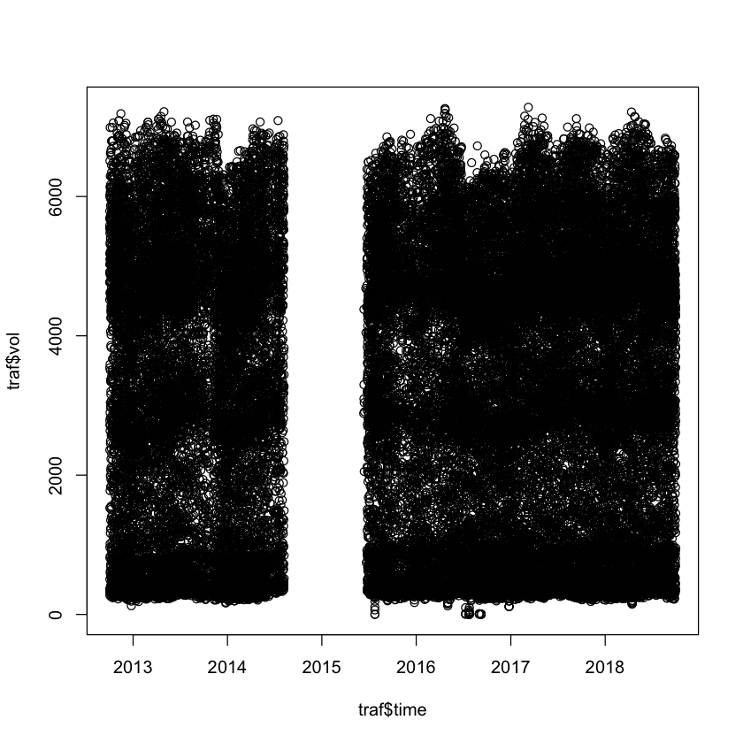

```r
library(data.table)
library(zoo)
library(xts)
library(stats)
library(lubridate)
library(forecast)
library(tidyverse)
library(corrplot)

# import data
traf <- fread("/Users/nevalgunal/Downloads/Metro_Interstate_Traffic_Volume.csv")
rename_traf <- c("holi", "temp", "rain", "snow", "clouds", "main", "desc", "time", "vol")
setnames(traf, names(traf), rename_traf)
summary(traf)
#numeric
traf$temp <- as.numeric(traf$temp)
traf$rain <- as.numeric(traf$rain)
traf$snow <- as.numeric(traf$snow)
traf$clouds <- as.numeric(traf$clouds)
traf$vol <- as.numeric(traf$vol)
traf$time <- as.POSIXct(traf$time, format="%Y-%m-%d %H:%M:%S")
#there are some duplicates
plot(traf$time, traf$vol)
```

As we can see in the figure, the data has a huge gap. The gap is filled with previous year data as shown below. Also, the duplicated are removed and missing values are added with the previous hour data.

```r
traf_dup = !duplicated(traf$time)
traf_notdup=traf[traf_dup,]
#get in order
traf_notdup=traf_notdup[order(time)]
# add the missing data between 2014-08-08 01:00:00 and
#2015-06-11 20:00:00
add_traf<- traf_notdup[time<"2014-06-11 20:00:00"]
add_traf<- add_traf[time>"2013-08-08 01:00:00"]
add_time<- as.POSIXct(add_traf$time)
add_time<- add_time %m+% years(1)
add_traf$time<-add_time
traf_part1 <- traf_notdup[time<="2014-08-08 01:00:00"]
traf_part3 <- traf_notdup[time>="2015-06-11 20:00:00"]
traf_total<- rbind(traf_part1, add_traf, traf_part3)

# add missing data with the data of previous hour
traf_loop<-traf_total
for (i in 1:nrow(traf_loop)+1){
  if (traf_loop$time[i]-hours(1) != traf_loop$time[i-1]){
    add_new_data<-traf_loop[i-1]
    add_new_data$time<-add_new_data$time+hours(1)
    part1<-traf_loop[time<traf_loop$time[i]]
    part2<-traf_loop[time>=traf_loop$time[i]]
    traf_loop <- rbind(part1,add_new_data,part2)
  }
}
```

The lagged values are also added to the data to use in models.

```r
# add lagged variables for future work
traf_frame<- as.data.table(traf_loop)
temp_lagged<-lag(traf_frame$temp, k=2)
temp_lagged[1]<-traf_frame$temp[1]
holi_lagged<-lag(traf_frame$holi, k=2)
holi_lagged[1]<-traf_frame$holi[1]
rain_lagged<-lag(traf_frame$rain, k=2)
rain_lagged[1]<-traf_frame$rain[1]
snow_lagged<-lag(traf_frame$snow, k=2)
snow_lagged[1]<-traf_frame$snow[1]
clouds_lagged<-lag(traf_frame$clouds, k=2)
clouds_lagged[1]<-traf_frame$clouds[1]
vol_lagged<-lag(as.vector(traf_frame$vol), k=2)
vol_lagged[1]<-as.vector(traf_frame$vol)[1]
traf_frame<-cbind(traf_frame,temp_lagged, holi_lagged,rain_lagged,snow_lagged,clouds_lagged,vol_lagged)
holi_index<-NULL
holi_index<-data.frame(holi_index)
for (i in 1:nrow(traf_frame)){
  if (traf_frame$holi[i]=="None"){
    bool=0
    holi_index=rbind(holi_index, bool)
  }else{
    bool=1
    holi_index=rbind(holi_index, bool)
  }
}
setnames(holi_index, names(holi_index), c("holi_ind"))

holi_index_lagged<-NULL
holi_index_lagged<-data.frame(holi_index_lagged)
for (i in 1:nrow(traf_frame)){
  if (traf_frame$holi_lagged[i]=="None"){
    bool_lagged=0
    holi_index_lagged=rbind(holi_index_lagged, bool_lagged)
  }else{
    bool_lagged=1
    holi_index_lagged=rbind(holi_index_lagged, bool_lagged)
  }
}
setnames(holi_index_lagged, names(holi_index_lagged), c("holi_lag_ind"))
#adding indexed holi columns
traf_frame<-cbind(traf_frame,holi_index,holi_index_lagged)
head(traf_frame)
```

| holi | temp | rain | snow | clouds | main | desc | time | vol | temp_lagged | holi_lagged | rain_lagged | snow_lagged | clouds_lagged | vol_lagged | holi_ind | holi_lag_ind |
| --- | --- | --- | --- | --- | --- | --- | --- | --- | --- | --- | --- | --- | --- | --- | --- | --- |
| None | 288.28 | 0 | 0 | 40 | Clouds | scattered clouds | 2012-10-02 09:00:00 | 5545 | 288.28 | None | 0 | 0 | 40 | 5545 | 0 | 0 |
| None | 289.36 | 0 | 0 | 75 | Clouds | broken clouds | 2012-10-02 10:00:00 | 4516 | 288.28 | None | 0 | 0 | 40 | 5545 | 0 | 0 |
| None | 289.58 | 0 | 0 | 90 | Clouds | overcast clouds | 2012-10-02 11:00:00 | 4767 | 289.36 | None | 0 | 0 | 75 | 4516 | 0 | 0 |
| None | 290.13 | 0 | 0 | 90 | Clouds | overcast clouds | 2012-10-02 12:00:00 | 5026 | 289.58 | None | 0 | 0 | 90 | 4767 | 0 | 0 |
| None | 291.14 | 0 | 0 | 75 | Clouds | broken clouds | 2012-10-02 13:00:00 | 4918 | 290.13 | None | 0 | 0 | 90 | 5026 | 0 | 0 |
| None | 291.72 | 0 | 0 | 1 | Clear | sky is clear | 2012-10-02 14:00:00 | 5181 | 291.14 | None | 0 | 0 | 75 | 4918 | 0 | 0 |

Then, the correlations are checked in order to decide which data can be used as regressors in the code below. However, no significant correlation is found.

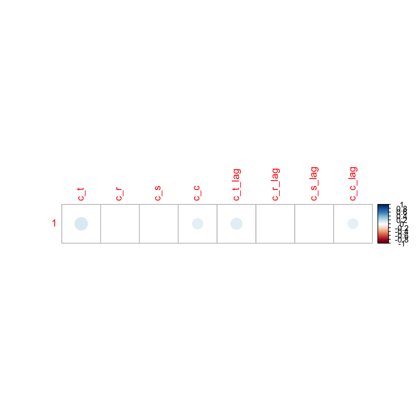

```r
#check correlation for future work
c_t<-cor(traf_frame$vol, traf_frame$temp)
c_r<-cor(traf_frame$vol, traf_frame$rain)
c_s<-cor(traf_frame$vol, traf_frame$snow)
c_c<-cor(traf_frame$vol, traf_frame$clouds)
c_t_lag<-cor(traf_frame$vol, traf_frame$temp_lagged)
c_r_lag<-cor(traf_frame$vol, traf_frame$rain_lagged)
c_s_lag<-cor(traf_frame$vol, traf_frame$snow_lagged)
c_c_lag<-cor(traf_frame$vol, traf_frame$clouds_lagged)
cor_vol<-cbind(c_t,c_r,c_s,c_c,c_t_lag,c_r_lag,c_s_lag,c_c_lag)
corrplot(cor_vol)
#no significant correlation
```

The frequency of the data is found by decomposing the data at different levels with the code below. It is found that the data has both hourly and daily seasonality, meaning that the frequency is equal to 168.

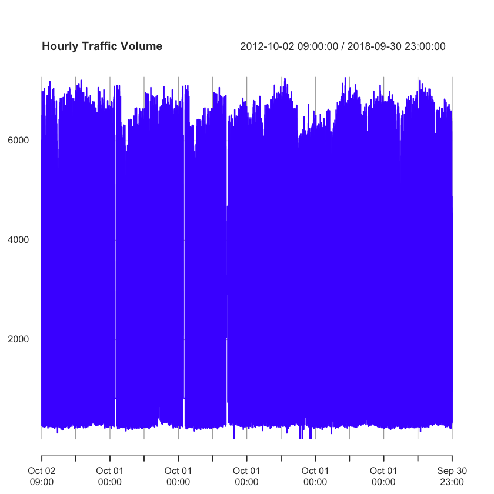

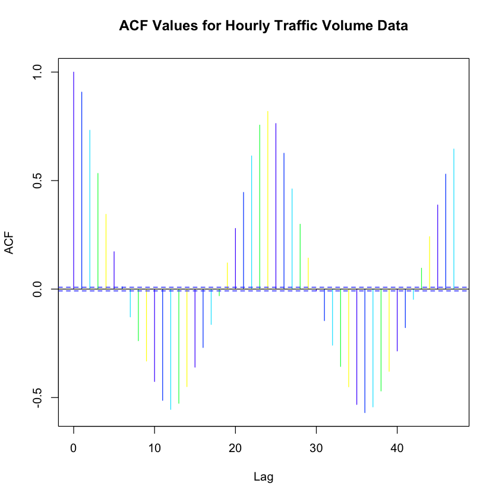

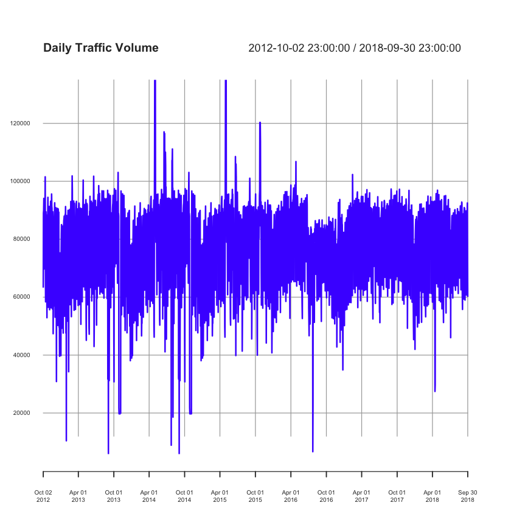

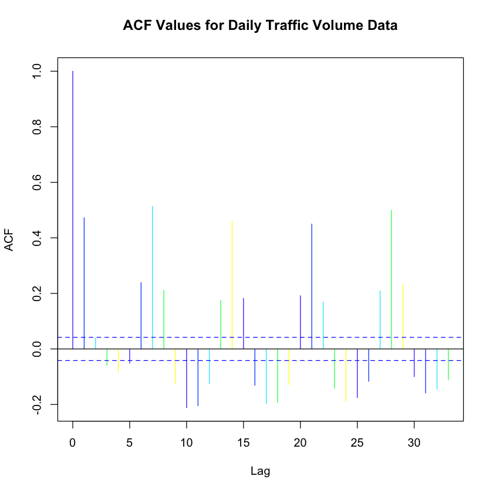

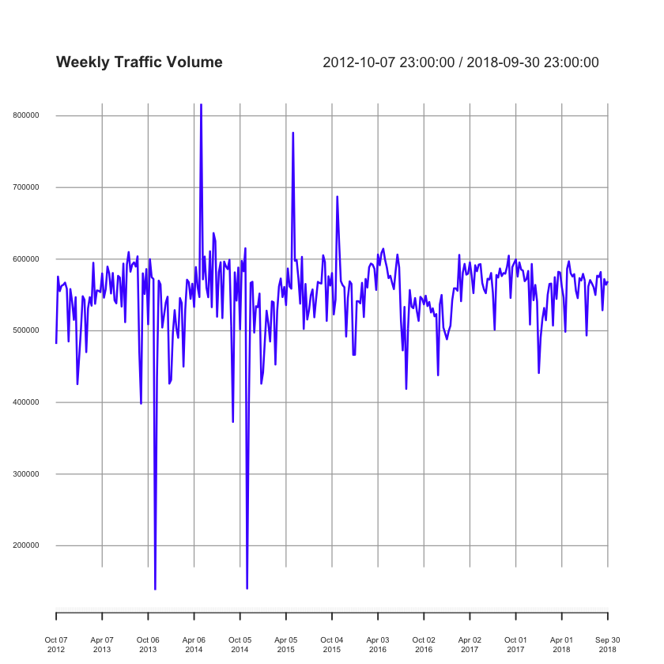

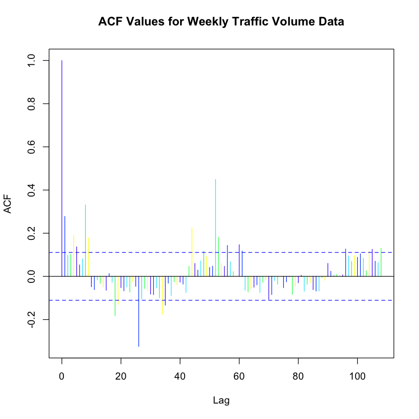

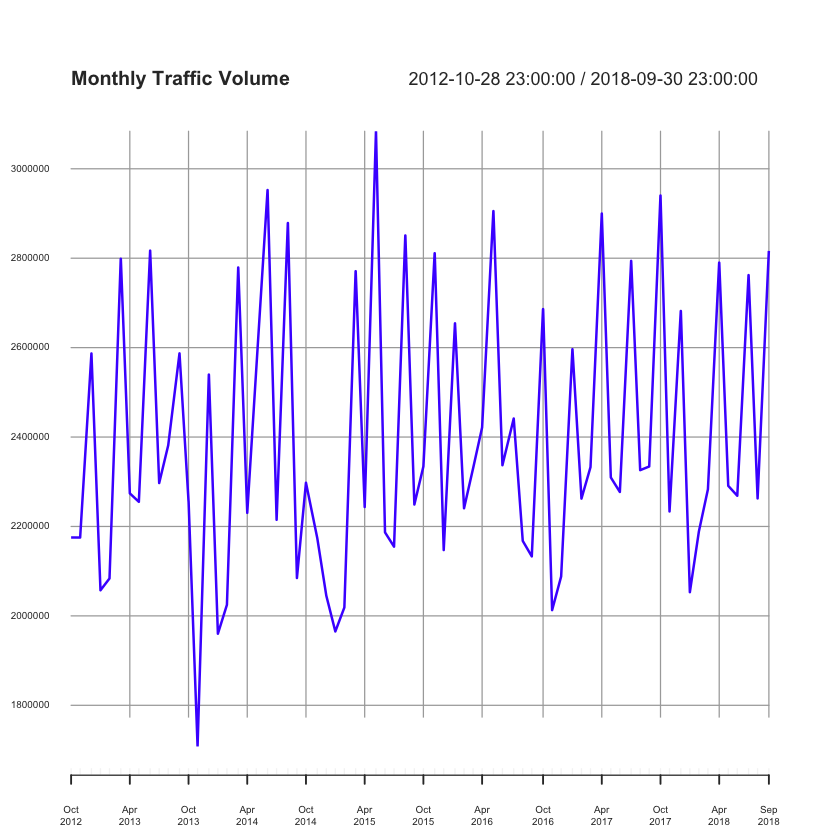

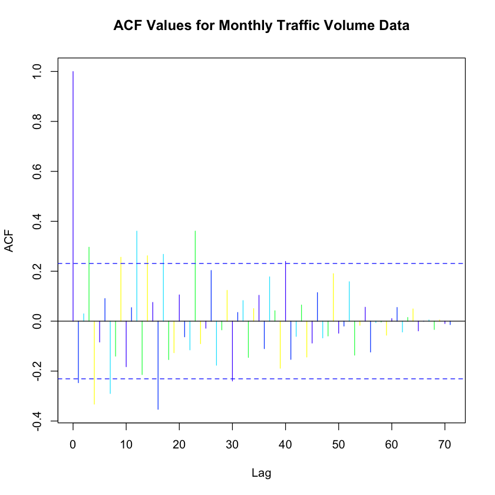

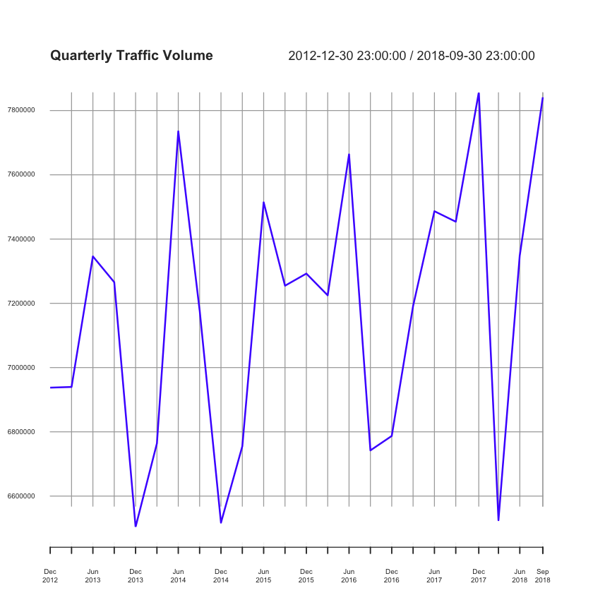

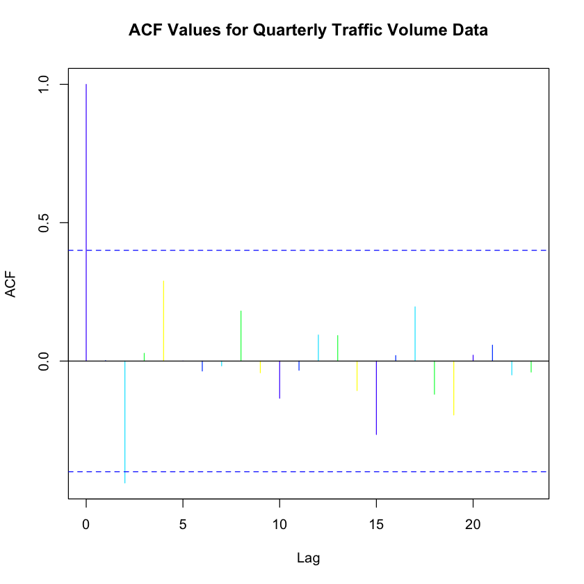

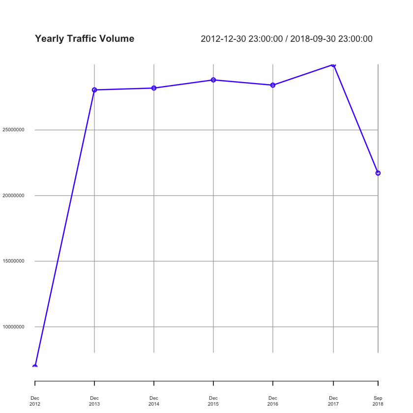

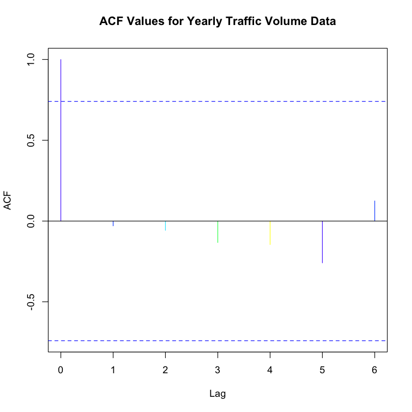

[2 more figures not shown]

```r
#decompose the series at different levels to find the frequency of the data
traf_hourly_xts<-xts(traf_loop$vol, order.by = traf_loop$time)
traf_hourly_ts<-ts(traf_hourly_xts)
plot.xts(traf_hourly_xts, main="Hourly Traffic Volume", xlab="Time", ylab="Traffic Volume", yaxis.right = FALSE, col=topo.colors(5))
acf(traf_hourly_ts, main="ACF Values for Hourly Traffic Volume Data", col=topo.colors(5))
# it gives negative relation in every 12 hours and positive relation in every 24 hours
traf_daily_xts<-apply.daily(traf_hourly_xts, FUN="sum")
traf_daily_ts<-ts(traf_daily_xts)
plot.xts(traf_daily_xts, main="Daily Traffic Volume", xlab="Time", ylab="Traffic Volume", yaxis.right = FALSE,  cex.axis=0.55, col=topo.colors(5))
acf(traf_daily_ts,main="ACF Values for Daily Traffic Volume Data", col=topo.colors(5))
# it gives positive relation in every 7 days
traf_weekly_xts<-apply.weekly(traf_daily_xts, FUN="sum")
traf_weekly_ts<-ts(traf_weekly_xts)
plot.xts(traf_weekly_xts, main="Weekly Traffic Volume", xlab="Time", ylab="Traffic Volume", yaxis.right = FALSE,  cex.axis=0.55, col=topo.colors(5))
acf(traf_weekly_ts,main="ACF Values for Weekly Traffic Volume Data", lag.max = 108, col=topo.colors(5))
# no significant relation(no pattern)
traf_monthly_xts<-apply.monthly(traf_weekly_xts, FUN="sum")
traf_monthly_ts<-ts(traf_monthly_xts)
plot.xts(traf_monthly_xts, main="Monthly Traffic Volume", xlab="Time", ylab="Traffic Volume", yaxis.right = FALSE,  cex.axis=0.55, col=topo.colors(5))
acf(traf_monthly_ts,main="ACF Values for Monthly Traffic Volume Data", lag.max = 100, col=topo.colors(5))
#no significant relation
traf_quarterly_xts<-apply.quarterly(traf_weekly_xts, FUN="sum")
traf_quarterly_ts<-ts(traf_quarterly_xts)
plot.xts(traf_quarterly_xts, main="Quarterly Traffic Volume", xlab="Time", ylab="Traffic Volume", yaxis.right = FALSE,  cex.axis=0.55, col=topo.colors(5))
acf(traf_quarterly_ts,main="ACF Values for Quarterly Traffic Volume Data", lag.max = 100, col=topo.colors(5))
#no significant relation
traf_yearly_xts<-apply.yearly(traf_weekly_xts, FUN="sum")
traf_yearly_ts<-ts(traf_yearly_xts)
plot.xts(traf_yearly_xts, main="Yearly Traffic Volume", xlab="Time", ylab="Traffic Volume", yaxis.right = FALSE,  cex.axis=0.55, type="o", col=topo.colors(5))
acf(traf_yearly_ts,main="ACF Values for Yearly Traffic Volume Data", lag.max = 100, col=topo.colors(5))
#no significant relation
# it is found that frequency is 24*7=168
traf_with_freq<-ts(traf_loop$vol, frequency=168)
plot(traf_with_freq, main="Traffic Volume Data with 168 Frequency",ylab="Traffic Volume", col=topo.colors(5))
# monthplot
monthplot(traf_monthly_xts,ylab="Traffic Volume",xlab="Month",xaxt="n",
          main="Average Values of Traffic Volume Data for Different Months", col=topo.colors(5))
axis(1,at=1:12,labels=month.abb,cex=0.8)
```

The train and test data is also created to understand whether the predictions are successful or not at the end of the analysis.

```r
train_traf=traf_loop[time<"2018-01-01 00:00:00"]
summary(train_traf)
test_traf=traf_loop[time>"2017-12-31 23:00:00"]
test_traf=test_traf[time<"2019-01-01 00:00:00"]
summary(test_traf)
```

```
     holi                temp            rain               snow
 Length:45999       Min.   :  0.0   Min.   :   0.000   Min.   :0.00000
 Class :character   1st Qu.:271.4   1st Qu.:   0.000   1st Qu.:0.00000
 Mode  :character   Median :280.8   Median :   0.000   Median :0.00000
                    Mean   :280.2   Mean   :   0.303   Mean   :0.00016
                    3rd Qu.:291.1   3rd Qu.:   0.000   3rd Qu.:0.00000
                    Max.   :308.2   Max.   :9831.300   Max.   :0.51000
     clouds           main               desc
 Min.   :  0.00   Length:45999       Length:45999
 1st Qu.:  1.00   Class :character   Class :character
 Median : 40.00   Mode  :character   Mode  :character
 Mean   : 45.17
 3rd Qu.: 90.00
 Max.   :100.00
      time                          vol
 Min.   :2012-10-02 09:00:00   Min.   :   0
 1st Qu.:2014-01-24 12:30:00   1st Qu.:1178
 Median :2015-05-18 16:00:00   Median :3370
 Mean   :2015-05-18 15:36:24   Mean   :3270
 3rd Qu.:2016-09-08 19:30:00   3rd Qu.:4978
 Max.   :2017-12-31 23:00:00   Max.   :7280
```

```
     holi                temp            rain              snow
 Length:6535        Min.   :247.1   Min.   : 0.0000   Min.   :0
 Class :character   1st Qu.:271.7   1st Qu.: 0.0000   1st Qu.:0
 Mode  :character   Median :287.2   Median : 0.0000   Median :0
                    Mean   :282.9   Mean   : 0.0656   Mean   :0
                    3rd Qu.:294.6   3rd Qu.: 0.0000   3rd Qu.:0
                    Max.   :310.1   Max.   :10.6000   Max.   :0
     clouds         main               desc
 Min.   : 0.0   Length:6535        Length:6535
 1st Qu.: 1.0   Class :character   Class :character
 Median :40.0   Mode  :character   Mode  :character
 Mean   :39.7
 3rd Qu.:90.0
 Max.   :92.0
      time                          vol
 Min.   :2018-01-01 00:00:00   Min.   : 151
 1st Qu.:2018-03-10 02:00:00   1st Qu.:1287
 Median :2018-05-17 15:00:00   Median :3511
 Mean   :2018-05-17 12:33:57   Mean   :3323
 3rd Qu.:2018-07-24 17:30:00   3rd Qu.:4952
 Max.   :2018-09-30 23:00:00   Max.   :7213
```

After, the trend and seasonality is found by using moving average model, linear regression model, Fourier series, and decompose function. However, the determined values could not use successfully to create meaningful models. For this reason, the rest of the analysis has sigificant flaws.

| time | vol | time_index |
| --- | --- | --- |
| 2012-10-02 09:00:00 | 5545 | 1 |
| 2012-10-02 10:00:00 | 4516 | 2 |
| 2012-10-02 11:00:00 | 4767 | 3 |
| 2012-10-02 12:00:00 | 5026 | 4 |
| 2012-10-02 13:00:00 | 4918 | 5 |
| 2012-10-02 14:00:00 | 5181 | 6 |
| 2012-10-02 15:00:00 | 5584 | 7 |
| 2012-10-02 16:00:00 | 6015 | 8 |
| 2012-10-02 17:00:00 | 5791 | 9 |
| 2012-10-02 18:00:00 | 4770 | 10 |
| 2012-10-02 19:00:00 | 3539 | 11 |
| 2012-10-02 20:00:00 | 2784 | 12 |
| 2012-10-02 21:00:00 | 2361 | 13 |
| 2012-10-02 22:00:00 | 1529 | 14 |
| 2012-10-02 23:00:00 | 963 | 15 |
| 2012-10-03 00:00:00 | 506 | 16 |
| 2012-10-03 01:00:00 | 321 | 17 |
| 2012-10-03 02:00:00 | 273 | 18 |
| 2012-10-03 03:00:00 | 367 | 19 |
| 2012-10-03 04:00:00 | 814 | 20 |
| 2012-10-03 05:00:00 | 2718 | 21 |
| 2012-10-03 06:00:00 | 5673 | 22 |
| 2012-10-03 07:00:00 | 5673 | 23 |
| 2012-10-03 08:00:00 | 6511 | 24 |
| 2012-10-03 09:00:00 | 5471 | 25 |
| 2012-10-03 10:00:00 | 5471 | 26 |
| 2012-10-03 11:00:00 | 5471 | 27 |
| 2012-10-03 12:00:00 | 5097 | 28 |
| 2012-10-03 13:00:00 | 4887 | 29 |
| 2012-10-03 14:00:00 | 5337 | 30 |
| ... | ... | ... |
| 2017-12-30 18:00:00 | 4514 | 45970 |
| 2017-12-30 19:00:00 | 3380 | 45971 |
| 2017-12-30 20:00:00 | 2597 | 45972 |
| 2017-12-30 21:00:00 | 2271 | 45973 |
| 2017-12-30 22:00:00 | 2352 | 45974 |
| 2017-12-30 23:00:00 | 2680 | 45975 |
| 2017-12-31 00:00:00 | 1000 | 45976 |
| 2017-12-31 01:00:00 | 711 | 45977 |
| 2017-12-31 02:00:00 | 519 | 45978 |
| 2017-12-31 03:00:00 | 303 | 45979 |
| 2017-12-31 04:00:00 | 285 | 45980 |
| 2017-12-31 05:00:00 | 457 | 45981 |
| 2017-12-31 06:00:00 | 808 | 45982 |
| 2017-12-31 07:00:00 | 959 | 45983 |
| 2017-12-31 08:00:00 | 1319 | 45984 |
| 2017-12-31 09:00:00 | 2384 | 45985 |
| 2017-12-31 10:00:00 | 3504 | 45986 |
| 2017-12-31 11:00:00 | 3404 | 45987 |
| 2017-12-31 12:00:00 | 3438 | 45988 |
| 2017-12-31 13:00:00 | 3212 | 45989 |
| 2017-12-31 14:00:00 | 3410 | 45990 |
| 2017-12-31 15:00:00 | 3635 | 45991 |
| 2017-12-31 16:00:00 | 3802 | 45992 |
| 2017-12-31 17:00:00 | 3513 | 45993 |
| 2017-12-31 18:00:00 | 3350 | 45994 |
| 2017-12-31 19:00:00 | 2995 | 45995 |
| 2017-12-31 20:00:00 | 2731 | 45996 |
| 2017-12-31 21:00:00 | 2483 | 45997 |
| 2017-12-31 22:00:00 | 2041 | 45998 |
| 2017-12-31 23:00:00 | 1580 | 45999 |

```
Call:
lm(formula = vol ~ time_index, data = for_trend)

Residuals:
    Min      1Q  Median      3Q     Max
-3303.9 -2090.8   101.7  1702.8  4001.9

Coefficients:
             Estimate Std. Error t value Pr(>|t|)
(Intercept) 3.200e+03  1.866e+01 171.476  < 2e-16 ***
time_index  3.048e-03  7.026e-04   4.338 1.44e-05 ***
---
Signif. codes:  0 ‘***’ 0.001 ‘**’ 0.01 ‘*’ 0.05 ‘.’ 0.1 ‘ ’ 1

Residual standard error: 2001 on 45997 degrees of freedom
Multiple R-squared:  0.0004089,	Adjusted R-squared:  0.0003872
F-statistic: 18.82 on 1 and 45997 DF,  p-value: 1.443e-05
```

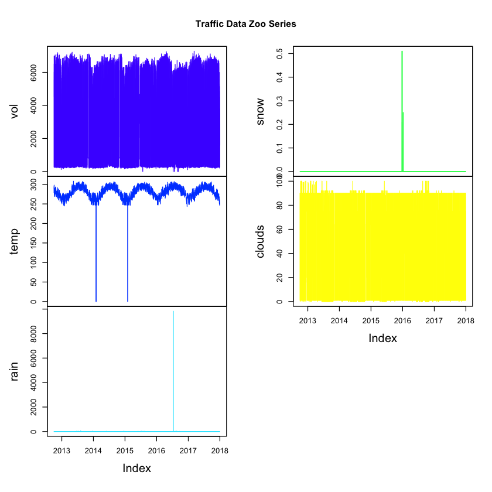

| time | vol | time_index | lr_trend | ma_trend |
| --- | --- | --- | --- | --- |
| 2012-10-02 09:00:00 | 5545 | 1 | 3199.760 | NA |
| 2012-10-02 10:00:00 | 4516 | 2 | 3199.763 | NA |
| 2012-10-02 11:00:00 | 4767 | 3 | 3199.766 | NA |
| 2012-10-02 12:00:00 | 5026 | 4 | 3199.769 | NA |
| 2012-10-02 13:00:00 | 4918 | 5 | 3199.772 | NA |
| 2012-10-02 14:00:00 | 5181 | 6 | 3199.775 | NA |
| 2012-10-02 15:00:00 | 5584 | 7 | 3199.778 | NA |
| 2012-10-02 16:00:00 | 6015 | 8 | 3199.781 | NA |
| 2012-10-02 17:00:00 | 5791 | 9 | 3199.784 | NA |
| 2012-10-02 18:00:00 | 4770 | 10 | 3199.787 | NA |
| 2012-10-02 19:00:00 | 3539 | 11 | 3199.790 | NA |
| 2012-10-02 20:00:00 | 2784 | 12 | 3199.794 | NA |
| 2012-10-02 21:00:00 | 2361 | 13 | 3199.797 | NA |
| 2012-10-02 22:00:00 | 1529 | 14 | 3199.800 | NA |
| 2012-10-02 23:00:00 | 963 | 15 | 3199.803 | NA |
| 2012-10-03 00:00:00 | 506 | 16 | 3199.806 | NA |
| 2012-10-03 01:00:00 | 321 | 17 | 3199.809 | NA |
| 2012-10-03 02:00:00 | 273 | 18 | 3199.812 | NA |
| 2012-10-03 03:00:00 | 367 | 19 | 3199.815 | NA |
| 2012-10-03 04:00:00 | 814 | 20 | 3199.818 | NA |
| 2012-10-03 05:00:00 | 2718 | 21 | 3199.821 | NA |
| 2012-10-03 06:00:00 | 5673 | 22 | 3199.824 | NA |
| 2012-10-03 07:00:00 | 5673 | 23 | 3199.827 | NA |
| 2012-10-03 08:00:00 | 6511 | 24 | 3199.830 | NA |
| 2012-10-03 09:00:00 | 5471 | 25 | 3199.833 | NA |
| 2012-10-03 10:00:00 | 5471 | 26 | 3199.836 | NA |
| 2012-10-03 11:00:00 | 5471 | 27 | 3199.839 | NA |
| 2012-10-03 12:00:00 | 5097 | 28 | 3199.842 | NA |
| 2012-10-03 13:00:00 | 4887 | 29 | 3199.845 | NA |
| 2012-10-03 14:00:00 | 5337 | 30 | 3199.848 | NA |

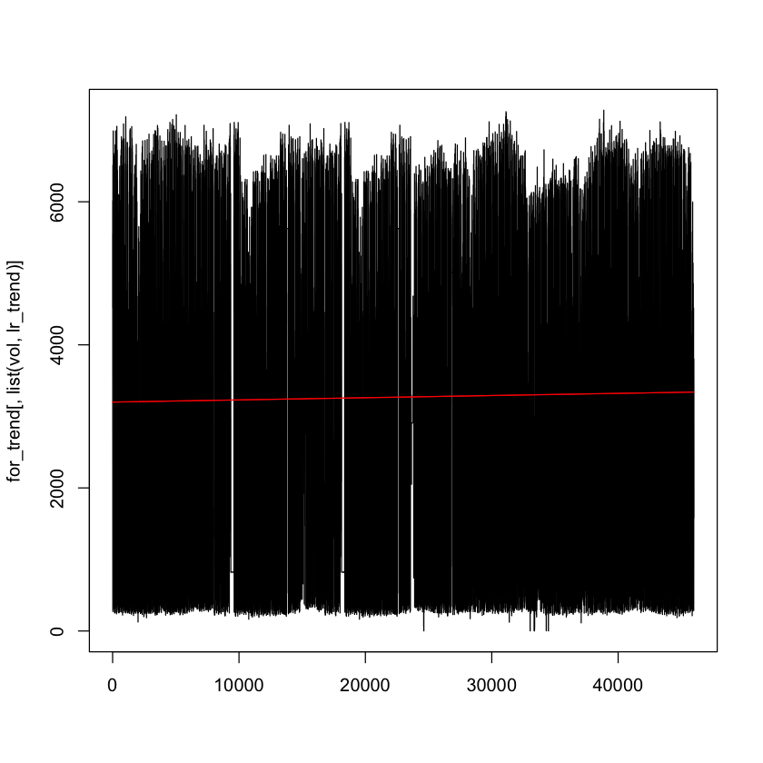

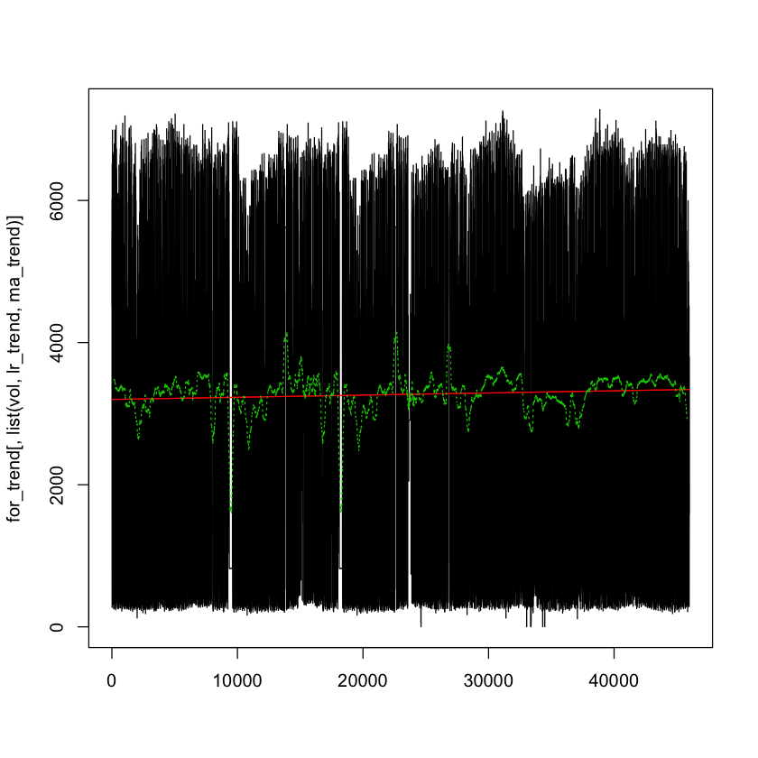

| time | vol | time_index | lr_trend | ma_trend | detrend_lr_traf | detrend_ma_traf |
| --- | --- | --- | --- | --- | --- | --- |
| 2012-10-02 09:00:00 | 5545 | 1 | 3199.760 | NA | 2345.240 | NA |
| 2012-10-02 10:00:00 | 4516 | 2 | 3199.763 | NA | 1316.237 | NA |
| 2012-10-02 11:00:00 | 4767 | 3 | 3199.766 | NA | 1567.234 | NA |
| 2012-10-02 12:00:00 | 5026 | 4 | 3199.769 | NA | 1826.231 | NA |
| 2012-10-02 13:00:00 | 4918 | 5 | 3199.772 | NA | 1718.228 | NA |
| 2012-10-02 14:00:00 | 5181 | 6 | 3199.775 | NA | 1981.225 | NA |

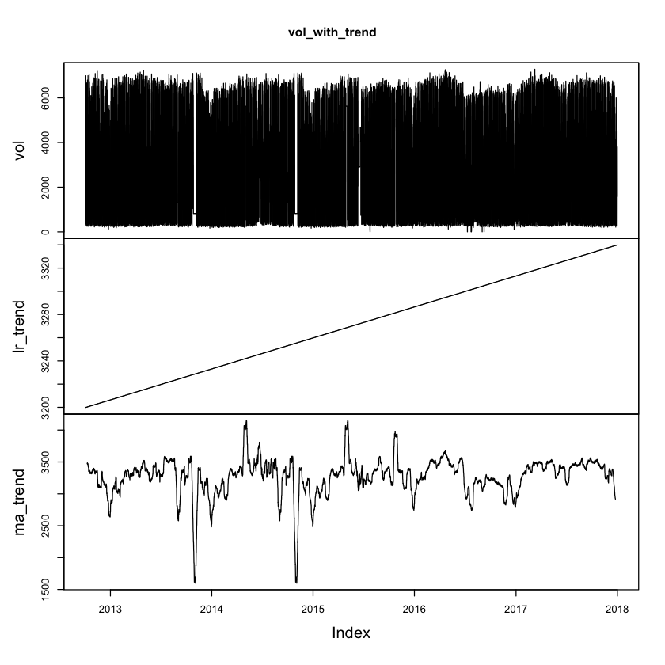

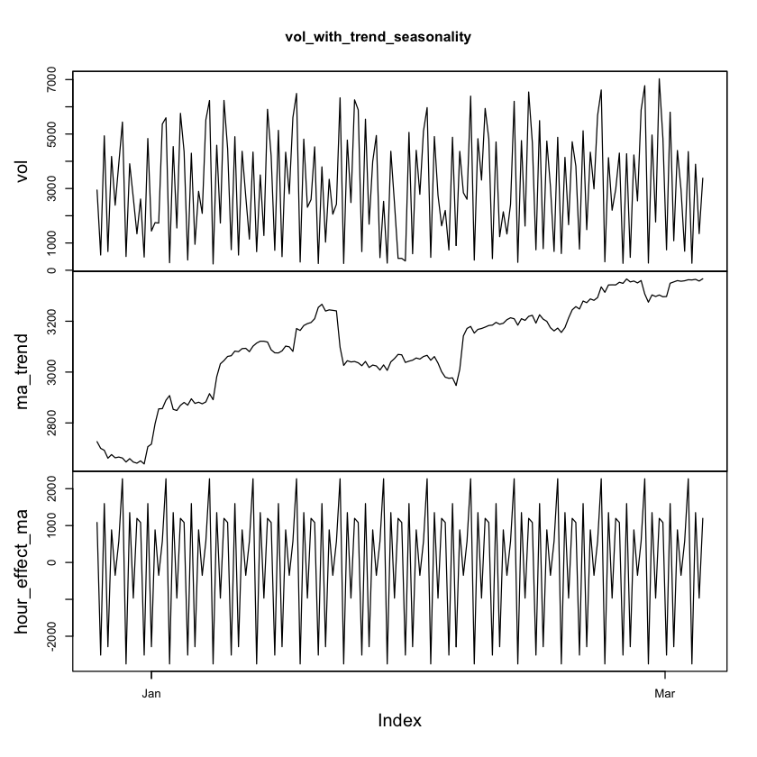

**daily_hourly_effect_lrFriday-0**

-2398.06245779786

**daily_hourly_effect_lrFriday-1**

-2695.39032308605

**daily_hourly_effect_lrFriday-10**

1292.74283092604

**daily_hourly_effect_lrFriday-11**

1576.85292184223

**daily_hourly_effect_lrFriday-12**

1830.77323173652

**daily_hourly_effect_lrFriday-13**

1833.07675330964

**daily_hourly_effect_lrFriday-14**

2068.65034787546

**daily_hourly_effect_lrFriday-15**

2363.91737309821

**daily_hourly_effect_lrFriday-16**

2696.72819394141

**daily_hourly_effect_lrFriday-17**

2283.98427025905

**daily_hourly_effect_lrFriday-18**

1486.72209840152

**daily_hourly_effect_lrFriday-19**

441.266495887045

**daily_hourly_effect_lrFriday-2**

-2824.56490370271

**daily_hourly_effect_lrFriday-20**

-150.827792758812

**daily_hourly_effect_lrFriday-21**

-245.188504762335

**daily_hourly_effect_lrFriday-22**

-539.173304357098

**daily_hourly_effect_lrFriday-23**

-1320.3223375285

**daily_hourly_effect_lrFriday-3**

-2798.66284198361

**daily_hourly_effect_lrFriday-4**

-2449.50165617691

**daily_hourly_effect_lrFriday-5**

-855.738280589193

**daily_hourly_effect_lrFriday-6**

1557.69662784524

**daily_hourly_effect_lrFriday-7**

2465.64978445486

**daily_hourly_effect_lrFriday-8**

1997.20878048053

**daily_hourly_effect_lrFriday-9**

1604.3371195719

**daily_hourly_effect_lrMonday-0**

-2422.7299833794

**daily_hourly_effect_lrMonday-1**

-2703.5498809662

**daily_hourly_effect_lrMonday-10**

717.195582877188

**daily_hourly_effect_lrMonday-11**

890.320740235448

**daily_hourly_effect_lrMonday-12**

1112.13454228235

**daily_hourly_effect_lrMonday-13**

1202.0728864538

**daily_hourly_effect_lrMonday-14**

1432.45445406847

**daily_hourly_effect_lrMonday-15**

1770.09975794687

**daily_hourly_effect_lrMonday-16**

2264.93187501209

**daily_hourly_effect_lrMonday-17**

1991.45996277328

**daily_hourly_effect_lrMonday-18**

856.504534050958

**daily_hourly_effect_lrMonday-19**

-162.315363535837

**daily_hourly_effect_lrMonday-2**

-2815.61886280208

**daily_hourly_effect_lrMonday-20**

-624.563832551204

**daily_hourly_effect_lrMonday-21**

-928.922191676461

**daily_hourly_effect_lrMonday-22**

-1467.45637497754

**daily_hourly_effect_lrMonday-23**

-2021.63890992698

**daily_hourly_effect_lrMonday-3**

-2825.39480434492

**daily_hourly_effect_lrMonday-4**

-2490.2952880123

**daily_hourly_effect_lrMonday-5**

-1122.4704969544

**daily_hourly_effect_lrMonday-6**

937.929385678582

**daily_hourly_effect_lrMonday-7**

1654.83842582072

**daily_hourly_effect_lrMonday-8**

1402.89398610939

**daily_hourly_effect_lrMonday-9**

980.227934676438

**daily_hourly_effect_lrSaturday-0**

-1960.95312252473

**daily_hourly_effect_lrSaturday-1**

-2401.94522138956

**daily_hourly_effect_lrSaturday-10**

695.103991016696

**daily_hourly_effect_lrSaturday-11**

1058.6958337577

**daily_hourly_effect_lrSaturday-12**

1373.40081518483

**daily_hourly_effect_lrSaturday-13**

1337.92331486014

**daily_hourly_effect_lrSaturday-14**

1365.01880723618

**daily_hourly_effect_lrSaturday-15**

1388.01575946624

**daily_hourly_effect_lrSaturday-16**

1420.70249271819

**daily_hourly_effect_lrSaturday-17**

1257.9950653862

**daily_hourly_effect_lrSaturday-18**

909.652601557862

**daily_hourly_effect_lrSaturday-19**

210.536415101785

**daily_hourly_effect_lrSaturday-2**

-2568.91907207922

**daily_hourly_effect_lrSaturday-20**

-239.565172814146

**daily_hourly_effect_lrSaturday-21**

-245.170410365113

**daily_hourly_effect_lrSaturday-22**

-270.22455302557

**daily_hourly_effect_lrSaturday-23**

-1018.62176137946

**daily_hourly_effect_lrSaturday-3**

-2722.71409065208

**daily_hourly_effect_lrSaturday-4**

-2688.66239389648

**daily_hourly_effect_lrSaturday-5**

-2194.20923728686

**daily_hourly_effect_lrSaturday-6**

-1417.23053323199

**daily_hourly_effect_lrSaturday-7**

-746.109493410694

**daily_hourly_effect_lrSaturday-8**

-145.842468187939

**daily_hourly_effect_lrSaturday-9**

366.851564334086

**daily_hourly_effect_lrSunday-0**

-1754.04816681364

**daily_hourly_effect_lrSunday-1**

-2290.35778392665

**daily_hourly_effect_lrSunday-10**

130.370260596399

**daily_hourly_effect_lrSunday-11**

472.867212826453

**daily_hourly_effect_lrSunday-12**

809.075843888625

**daily_hourly_effect_lrSunday-13**

898.612942104081

**daily_hourly_effect_lrSunday-14**

894.51135418815

**daily_hourly_effect_lrSunday-15**

917.256481600686

**daily_hourly_effect_lrSunday-16**

923.33737543658

**daily_hourly_effect_lrSunday-17**

765.900021097292

**daily_hourly_effect_lrSunday-18**

435.192593765302

**daily_hourly_effect_lrSunday-19**

-73.544030646979

**daily_hourly_effect_lrSunday-2**

-2507.22579520024

**daily_hourly_effect_lrSunday-20**

-474.412041920574

**daily_hourly_effect_lrSunday-21**

-771.980783121176

**daily_hourly_effect_lrSunday-22**

-1195.83784548966

**daily_hourly_effect_lrSunday-23**

-1814.34454289464

**daily_hourly_effect_lrSunday-3**

-2731.9405218023

**daily_hourly_effect_lrSunday-4**

-2787.30488344086

**daily_hourly_effect_lrSunday-5**

-2646.05245675825

**daily_hourly_effect_lrSunday-6**

-2296.73433664499

**daily_hourly_effect_lrSunday-7**

-1933.6643917142

**daily_hourly_effect_lrSunday-8**

-1291.50320590751

**daily_hourly_effect_lrSunday-9**

-568.644939808838

**daily_hourly_effect_lrThursday-0**

-2474.41631861844

**daily_hourly_effect_lrThursday-1**

-2762.35002332269

**daily_hourly_effect_lrThursday-10**

1218.06415258722

**daily_hourly_effect_lrThursday-11**

1396.18884204355

**daily_hourly_effect_lrThursday-12**

1573.24418843419

**daily_hourly_effect_lrThursday-13**

1611.29953482483

**daily_hourly_effect_lrThursday-14**

1918.66510019357

**daily_hourly_effect_lrThursday-15**

2324.40657797107

**daily_hourly_effect_lrThursday-16**

2892.02761779236

**daily_hourly_effect_lrThursday-17**

2621.75814666475

**daily_hourly_effect_lrThursday-18**

1386.76969743495

**daily_hourly_effect_lrThursday-19**

254.55497083289

**daily_hourly_effect_lrThursday-2**

-2870.82387401235

**daily_hourly_effect_lrThursday-20**

-228.586763068443

**daily_hourly_effect_lrThursday-21**

-324.801489670505

**daily_hourly_effect_lrThursday-22**

-877.826435250669

**daily_hourly_effect_lrThursday-23**

-1775.05576039288

**daily_hourly_effect_lrThursday-3**

-2826.71743273119

**daily_hourly_effect_lrThursday-4**

-2425.93215933326

**daily_hourly_effect_lrThursday-5**

-800.314769146998

**daily_hourly_effect_lrThursday-6**

1642.48875242612

**daily_hourly_effect_lrThursday-7**

2427.11709151749

**daily_hourly_effect_lrThursday-8**

2114.46805834608

**daily_hourly_effect_lrThursday-9**

1668.00515656154

**daily_hourly_effect_lrTuesday-0**

-2519.4661335211

**daily_hourly_effect_lrTuesday-1**

-2764.19445601632

**daily_hourly_effect_lrTuesday-10**

992.243292259927

**daily_hourly_effect_lrTuesday-11**

1127.83878463597

**daily_hourly_effect_lrTuesday-12**

1317.35033540617

**daily_hourly_effect_lrTuesday-13**

1365.39838252673

**daily_hourly_effect_lrTuesday-14**

1692.39168512175

**daily_hourly_effect_lrTuesday-15**

2127.19155705983

**daily_hourly_effect_lrTuesday-16**

2773.86734140668

**daily_hourly_effect_lrTuesday-17**

2509.4409359725

**daily_hourly_effect_lrTuesday-18**

1181.20796119525

**daily_hourly_effect_lrTuesday-19**

34.0297309435565

**daily_hourly_effect_lrTuesday-2**

-2863.68102026978

**daily_hourly_effect_lrTuesday-20**

-432.155798578214

**daily_hourly_effect_lrTuesday-21**

-631.129649267867

**daily_hourly_effect_lrTuesday-22**

-1203.0414561619

**daily_hourly_effect_lrTuesday-23**

-1931.86202218002

**daily_hourly_effect_lrTuesday-3**

-2806.99542335108

**daily_hourly_effect_lrTuesday-4**

-2386.06806819062

**daily_hourly_effect_lrTuesday-5**

-760.071115960567

**daily_hourly_effect_lrTuesday-6**

1758.64012198377

**daily_hourly_effect_lrTuesday-7**

2441.60410718086

**daily_hourly_effect_lrTuesday-8**

2041.66699347685

**daily_hourly_effect_lrTuesday-9**

1557.3886757963

**daily_hourly_effect_lrWednesday-0**

-2516.90521593537

**daily_hourly_effect_lrWednesday-1**

-2742.86811771991

**daily_hourly_effect_lrWednesday-10**

1163.11540125569

**daily_hourly_effect_lrWednesday-11**

1328.18169655144

**daily_hourly_effect_lrWednesday-12**

1479.08375827054

**daily_hourly_effect_lrWednesday-13**

1515.16465210644

**daily_hourly_effect_lrWednesday-14**

1843.81123937299

**daily_hourly_effect_lrWednesday-15**

2259.78264415779

**daily_hourly_effect_lrWednesday-16**

2945.49127521996

**daily_hourly_effect_lrWednesday-17**

2693.6670595668

**daily_hourly_effect_lrWednesday-18**

1352.5983183662

**daily_hourly_effect_lrWednesday-19**

194.952934829829

**daily_hourly_effect_lrWednesday-2**

-2865.48795381103

**daily_hourly_effect_lrWednesday-20**

-308.630404910919

**daily_hourly_effect_lrWednesday-21**

-618.972868739259

**daily_hourly_effect_lrWednesday-22**

-1239.97226687417

**daily_hourly_effect_lrWednesday-23**

-1906.16144603098

**daily_hourly_effect_lrWednesday-3**

-2808.85231544958

**daily_hourly_effect_lrWednesday-4**

-2403.77142161369

**daily_hourly_effect_lrWednesday-5**

-764.573739456628

**daily_hourly_effect_lrWednesday-6**

1838.56189890481

**daily_hourly_effect_lrWednesday-7**

2509.3617708429

**daily_hourly_effect_lrWednesday-8**

2255.27843110215

**daily_hourly_effect_lrWednesday-9**

1732.43961690885

```
Call:
lm(formula = detrend_lr_traf ~ -1 + weekday * hour, data = lr_sea_decomp_ser)

Residuals:
    Min      1Q  Median      3Q     Max
-5973.5  -222.9    -7.0   348.3  6150.2

Coefficients:
                         Estimate Std. Error t value Pr(>|t|)
weekdayFriday           -2398.062     53.628 -44.717  < 2e-16 ***
weekdayMonday           -2422.730     53.726 -45.094  < 2e-16 ***
weekdaySaturday         -1960.953     53.628 -36.566  < 2e-16 ***
weekdaySunday           -1754.048     53.628 -32.708  < 2e-16 ***
weekdayThursday         -2474.416     53.628 -46.140  < 2e-16 ***
weekdayTuesday          -2519.466     53.726 -46.895  < 2e-16 ***
weekdayWednesday        -2516.905     53.628 -46.933  < 2e-16 ***
hour1                    -297.328     75.841  -3.920 8.85e-05 ***
hour2                    -426.502     75.841  -5.624 1.88e-08 ***
hour3                    -400.600     75.841  -5.282 1.28e-07 ***
hour4                     -51.439     75.841  -0.678 0.497618
hour5                    1542.324     75.841  20.336  < 2e-16 ***
hour6                    3955.759     75.841  52.158  < 2e-16 ***
hour7                    4863.712     75.841  64.130  < 2e-16 ***
hour8                    4395.271     75.841  57.954  < 2e-16 ***
hour9                    4002.400     75.841  52.773  < 2e-16 ***
hour10                   3690.805     75.841  48.665  < 2e-16 ***
hour11                   3974.915     75.841  52.411  < 2e-16 ***
hour12                   4228.836     75.841  55.759  < 2e-16 ***
hour13                   4231.139     75.841  55.789  < 2e-16 ***
hour14                   4466.713     75.841  58.896  < 2e-16 ***
hour15                   4761.980     75.841  62.789  < 2e-16 ***
hour16                   5094.791     75.841  67.177  < 2e-16 ***
hour17                   4682.047     75.841  61.735  < 2e-16 ***
hour18                   3884.785     75.841  51.223  < 2e-16 ***
hour19                   2839.329     75.841  37.438  < 2e-16 ***
hour20                   2247.235     75.841  29.631  < 2e-16 ***
hour21                   2152.874     75.841  28.387  < 2e-16 ***
hour22                   1858.889     75.841  24.510  < 2e-16 ***
hour23                   1077.740     75.841  14.210  < 2e-16 ***
weekdayMonday:hour1        16.508    107.354   0.154 0.877791
```

[output cut: 128 more lines]

```
weekdayThursday:hour22   -262.299    107.256  -2.446 0.014467 *
weekdayTuesday:hour22    -542.464    107.305  -5.055 4.31e-07 ***
weekdayWednesday:hour22  -581.956    107.256  -5.426 5.80e-08 ***
weekdayMonday:hour23     -676.649    107.354  -6.303 2.95e-10 ***
weekdaySaturday:hour23   -135.409    107.256  -1.262 0.206781
weekdaySunday:hour23    -1138.036    107.256 -10.610  < 2e-16 ***
weekdayThursday:hour23   -378.380    107.256  -3.528 0.000419 ***
weekdayTuesday:hour23    -490.136    107.305  -4.568 4.94e-06 ***
weekdayWednesday:hour23  -466.996    107.256  -4.354 1.34e-05 ***
---
Signif. codes:  0 ‘***’ 0.001 ‘**’ 0.01 ‘*’ 0.05 ‘.’ 0.1 ‘ ’ 1

Residual standard error: 887.7 on 45831 degrees of freedom
Multiple R-squared:  0.8039,	Adjusted R-squared:  0.8032
F-statistic:  1118 on 168 and 45831 DF,  p-value: < 2.2e-16
```

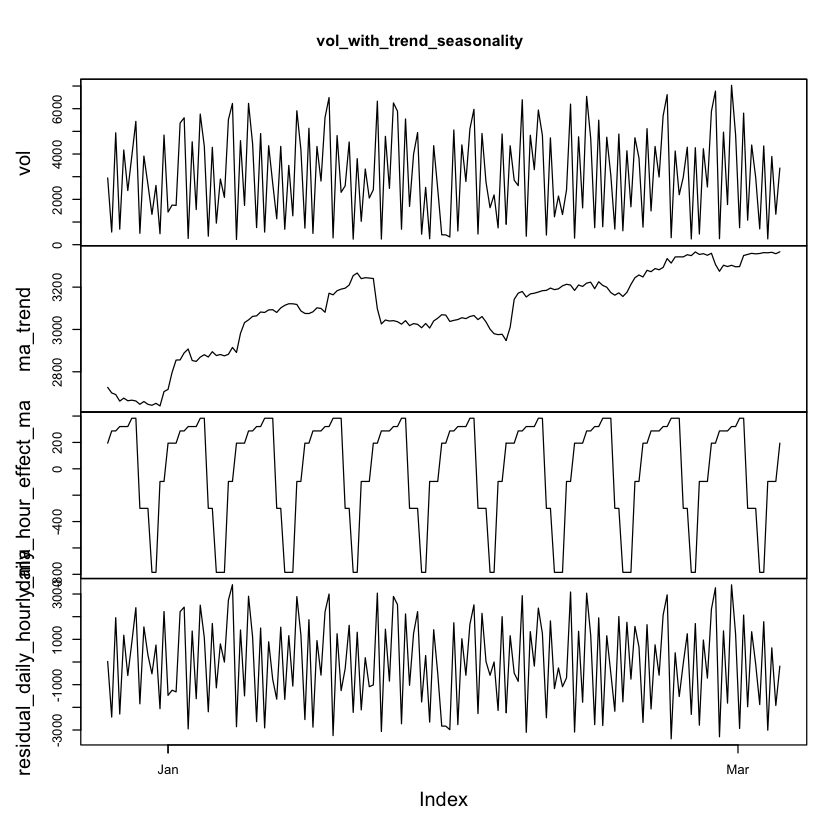

```
 num [1:45999, 1:8] 0.0374 0.0747 0.112 0.149 0.1859 ...
 - attr(*, "dimnames")=List of 2
  ..$ : NULL
  ..$ : chr [1:8] "S1-168" "C1-168" "S2-168" "C2-168" ...
```

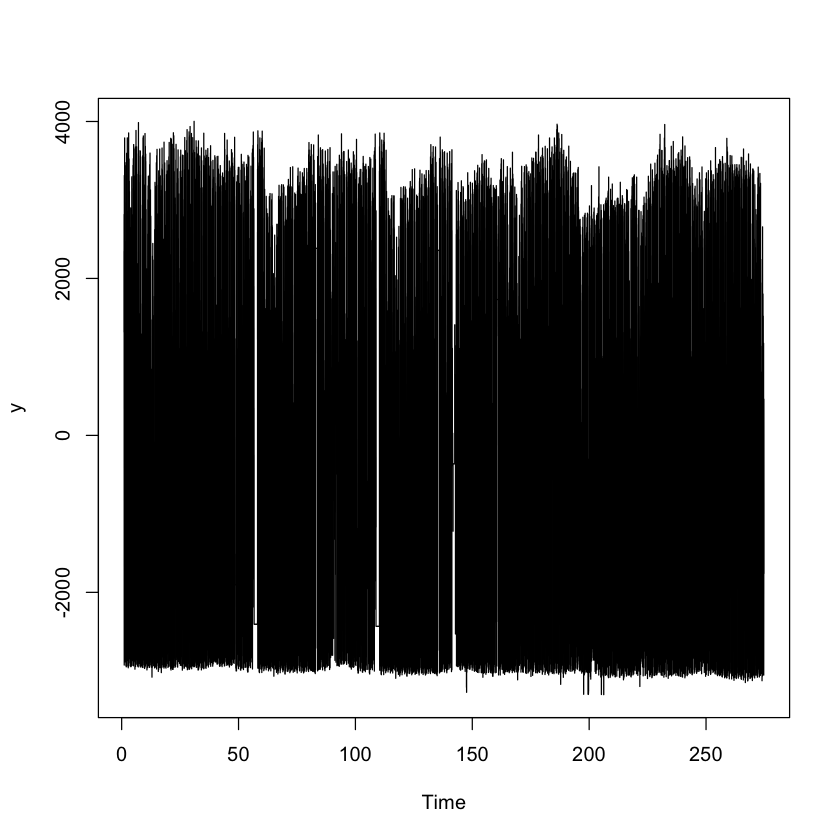

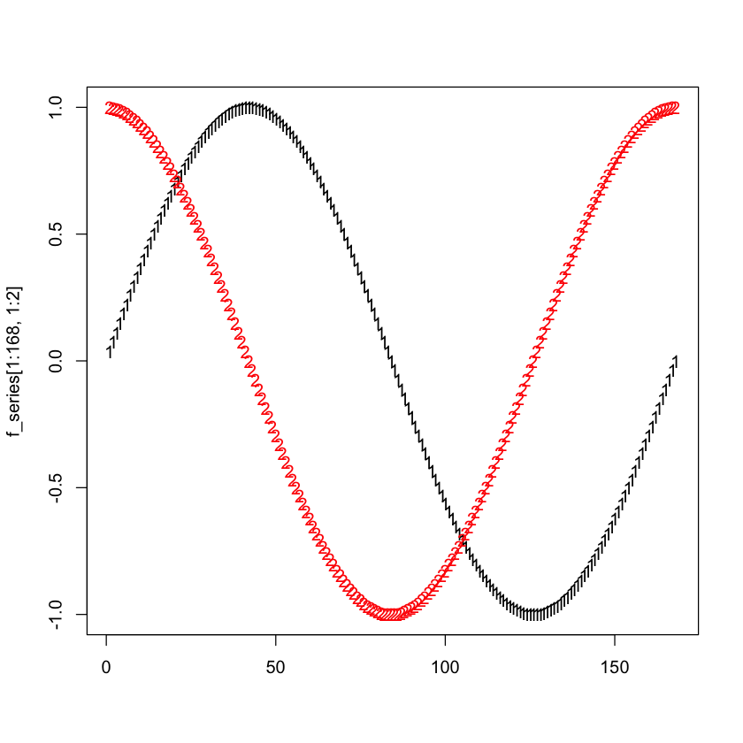

```
Error in checkresiduals(model_lr): No residuals found
Traceback:

1. checkresiduals(model_lr)
2. stop("No residuals found")
```

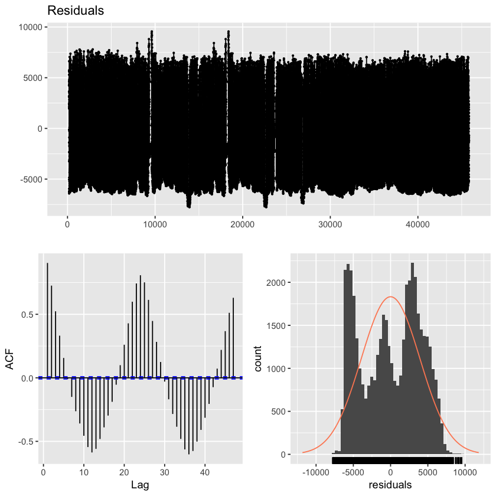

```r
# create zoo series
train_traf<-train_traf[order(time)]
traf_series<-zoo(train_traf[,list(vol,temp,rain,snow,clouds)], train_traf$time)
plot(traf_series, pch=5, cex=0.3, col=topo.colors(5), main = "Traffic Data Zoo Series")

# observe the trend in train data with LR model
for_trend <- train_traf[, list(time, vol)]
for_trend[, time_index:=1:.N]
for_trend
trend_lr <- lm(vol~time_index, for_trend)
summary(trend_lr)
for_trend[, lr_trend:=trend_lr$fitted.values]
matplot(for_trend[,list(vol, lr_trend)], type = "l")
# very little increase in volume over time

# use moving average approach
window_size=168 # buna frequencye göre karar vermemiz gerekiyor
for_trend[, ma_trend:=frollmean(vol, 2*window_size+1, align = "center")]
head(for_trend,30)
matplot(for_trend[,list(vol, lr_trend, ma_trend)], type = "l")
# plot
vol_with_trend=zoo(for_trend[, list(vol, lr_trend, ma_trend)], for_trend$time)
plot(vol_with_trend)

# Seasonality
for_trend[, detrend_lr_traf:=vol-lr_trend]
for_trend[, detrend_ma_traf:=vol-ma_trend]
head(for_trend)
for_trend$Date <- as.Date(for_trend$time)
for_trend$Time <- format(as.POSIXct(for_trend$time) ,format = "%H:%M:%S")
for_trend[,hour:=hour(time)]
for_trend[, hour_effect_ma:=mean(detrend_ma_traf, na.rm=TRUE), by=list(hour)]
#plot(for_trend[1:48]$hour_effect_lr,type="l")
vol1=for_trend[,list(time,vol,ma_trend,hour_effect_ma)]
vol1=vol1[168*10+1:168*10+24*14]
vol_with_trend_seasonality=zoo(vol1[,list(vol,ma_trend,hour_effect_ma)], vol1$time)
plot(vol_with_trend_seasonality)
for_trend[,weekday:=weekdays(time)]
for_trend[,daily_hour_effect_ma:=mean(detrend_ma_traf, na.rm=TRUE), by=list(weekday)]
for_trend[,residual_daily_hourly_ma:=detrend_ma_traf-daily_hour_effect_ma]
vol1=for_trend[,list(time,vol,ma_trend,daily_hour_effect_ma,residual_daily_hourly_ma)]
vol1=vol1[168*10+1:168*10+24*14]
vol_with_trend_seasonality=zoo(vol1[,list(vol,ma_trend, daily_hour_effect_ma, residual_daily_hourly_ma)], vol1$time)
plot(vol_with_trend_seasonality)

# by using categorical variable
lr_sea_decomp_ser=for_trend[, list(time, weekday, hour, vol, detrend_lr_traf, lr_trend)]
lr_sea_decomp_ser[, daily_hourly_effect_lr:=paste(weekday, hour, sep='-')] # a categorical predicter
lr_sea_decomp_ser[, time_index:=1:.N]
seas_lm=lm(detrend_lr_traf~-1+daily_hourly_effect_lr, lr_sea_decomp_ser) #without intercept
coef(seas_lm)
se=data.table(variable=attr(coef(seas_lm), "names"), value=as.numeric(coef(seas_lm)))
lr_sea_decomp_ser[, month:=as.factor(month(time))]
lr_sea_decomp_ser[,hour:=as.factor(hour)]
res<-lr_sea_decomp_ser$detrend_lr_traf-coef(se)
seas_lm2<-lm(detrend_lr_traf~-1+weekday*hour, lr_sea_decomp_ser) #multiple reg
summary(seas_lm2)

#modeling seasonality with Fourier Series(for continuity)
y=ts(lr_sea_decomp_ser$detrend_lr_traf, freq= 168)
plot(y)
f_series<-fourier(y, K=4)
str(f_series)
matplot(f_series[1:168, 1:2])
fit=lm(y~+f_series)


# modeling data with MA
model_ma=for_trend$detrend_ma_traf+for_trend$daily_hour_effect_ma+for_trend$residual_daily_hourly_ma
checkresiduals(model_ma)
model_lr=lr_sea_decomp_ser$detrend_lr_traf+f_series+res
checkresiduals(model_lr)
# I do not think that I can model the stationary data properly. Therefore, I do not continue with these models.

#ARIMA
traf_multip<-decompose(traf_with_freq, type="multiplicative")
plot(traf_multip)
ggAcf(traf_multip$random, main="ACF Values of Random Part of Multiplicative Decomposition")

traf_additive<-decompose(traf_with_freq,type="additive")
plot(traf_additive)
ggAcf(traf_additive$random, main="ACF Values of Random Part of Additive Decomposition")
#further check
test1 <- Box.test(traf_multip$random)
print(test1) # p is very small, less than 0.05. So it is a white noise.
test2 <- Box.test(traf_additive$random)
# print(test2) # again, p is very small, less than 0.05. So it is a white noise.

#deseasonalize
traf_deseasonalized <- traf_with_freq-traf_additive$seasonal
ts.plot(traf_deseasonalized, col=topo.colors(10), ylab="Vol", main="Deseasonilized Traffic Volume")
acf(traf_deseasonalized)
#there is still trend

#detrend
detrend <- traf_deseasonalized-traf_additive$trend
ts.plot(detrend, col=topo.colors(10), ylab="Vol", main="Deseasonilized and Detrended Traffic Volume", cex=0.1)
acf(detrend, na.action = na.pass)
plot(traf_additive$random, main="Random Noise of Traffic Volume Data", ylab="Random noise")
plot(detrend)
```

After these, the linear regression models are created to make predictions. However, as mentioned earlier, the model is very inaccurate.

```r
# Modeling Using Linear Regression
lr_sea_decomp_ser[, temp_lag:=traf_frame$temp_lag[1:45999]]
lr_sea_decomp_ser[, rain_lag:=traf_frame$rain_lag[1:45999]]
lr_sea_decomp_ser[, snow_lag:=traf_frame$snow_lag[1:45999]]
lr_sea_decomp_ser[, clouds_lag:=traf_frame$clouds_lag[1:45999]]
lr_sea_decomp_ser[, temp:=traf_frame$temp[1:45999]]
lr_sea_decomp_ser[, rain:=traf_frame$rain[1:45999]]
lr_sea_decomp_ser[, snow:=traf_frame$snow[1:45999]]
lr_sea_decomp_ser[, clouds:=traf_frame$clouds_lag[1:45999]]
lr_1=lm(vol~weekday+time_index+hour, data=lr_sea_decomp_ser)
summary(lr_1)
lr_2=lm(vol~weekday+time_index+hour+temp+rain+snow+clouds, data=lr_sea_decomp_ser)
summary(lr_2)
lr_3=lm(vol~weekday+time_index+hour+temp_lag+rain_lag+snow_lag+clouds_lag, data=lr_sea_decomp_ser)
summary(lr_3)
accuracy(lr_1)
accuracy(lr_2)
accuracy(lr_3)
```

```
Call:
lm(formula = vol ~ weekday + time_index + hour, data = lr_sea_decomp_ser)

Residuals:
    Min      1Q  Median      3Q     Max
-5590.7  -476.5    28.8   559.5  5960.0

Coefficients:
                   Estimate Std. Error t value Pr(>|t|)
(Intercept)       1.291e+03  2.777e+01  46.476  < 2e-16 ***
weekdayMonday    -4.831e+02  1.810e+01 -26.693  < 2e-16 ***
weekdaySaturday  -6.858e+02  1.808e+01 -37.927  < 2e-16 ***
weekdaySunday    -1.171e+03  1.808e+01 -64.784  < 2e-16 ***
weekdayThursday  -6.416e+01  1.808e+01  -3.549 0.000388 ***
weekdayTuesday   -1.919e+02  1.809e+01 -10.612  < 2e-16 ***
weekdayWednesday -9.528e+01  1.808e+01  -5.270 1.37e-07 ***
time_index        3.111e-03  3.640e-04   8.545  < 2e-16 ***
hour1            -3.307e+02  3.350e+01  -9.871  < 2e-16 ***
hour2            -4.672e+02  3.350e+01 -13.948  < 2e-16 ***
hour3            -4.965e+02  3.350e+01 -14.823  < 2e-16 ***
hour4            -2.267e+02  3.350e+01  -6.768 1.33e-11 ***
hour5             9.856e+02  3.350e+01  29.423  < 2e-16 ***
hour6             2.866e+03  3.350e+01  85.555  < 2e-16 ***
hour7             3.551e+03  3.350e+01 106.014  < 2e-16 ***
hour8             3.488e+03  3.350e+01 104.126  < 2e-16 ***
hour9             3.341e+03  3.349e+01  99.746  < 2e-16 ***
hour10            3.179e+03  3.349e+01  94.920  < 2e-16 ***
hour11            3.414e+03  3.349e+01 101.925  < 2e-16 ***
hour12            3.649e+03  3.349e+01 108.938  < 2e-16 ***
hour13            3.687e+03  3.349e+01 110.082  < 2e-16 ***
hour14            3.894e+03  3.349e+01 116.275  < 2e-16 ***
hour15            4.171e+03  3.349e+01 124.528  < 2e-16 ***
hour16            4.566e+03  3.349e+01 136.326  < 2e-16 ***
hour17            4.310e+03  3.349e+01 128.679  < 2e-16 ***
hour18            3.379e+03  3.349e+01 100.892  < 2e-16 ***
hour19            2.421e+03  3.349e+01  72.276  < 2e-16 ***
hour20            1.941e+03  3.349e+01  57.952  < 2e-16 ***
hour21            1.754e+03  3.349e+01  52.377  < 2e-16 ***
hour22            1.322e+03  3.349e+01  39.466  < 2e-16 ***
hour23            6.083e+02  3.349e+01  18.161  < 2e-16 ***
---
Signif. codes:  0 ‘***’ 0.001 ‘**’ 0.01 ‘*’ 0.05 ‘.’ 0.1 ‘ ’ 1

Residual standard error: 1037 on 45968 degrees of freedom
Multiple R-squared:  0.7318,	Adjusted R-squared:  0.7316
F-statistic:  4181 on 30 and 45968 DF,  p-value: < 2.2e-16
```

```
Call:
lm(formula = vol ~ weekday + time_index + hour + temp + rain +
    snow + clouds, data = lr_sea_decomp_ser)

Residuals:
    Min      1Q  Median      3Q     Max
-5625.5  -471.2    27.0   556.7  5902.5

Coefficients:
                   Estimate Std. Error t value Pr(>|t|)
(Intercept)      -8.516e+02  1.004e+02  -8.482  < 2e-16 ***
weekdayMonday    -4.871e+02  1.800e+01 -27.066  < 2e-16 ***
weekdaySaturday  -6.831e+02  1.798e+01 -37.986  < 2e-16 ***
weekdaySunday    -1.170e+03  1.798e+01 -65.096  < 2e-16 ***
weekdayThursday  -6.702e+01  1.798e+01  -3.727 0.000194 ***
weekdayTuesday   -1.933e+02  1.799e+01 -10.748  < 2e-16 ***
weekdayWednesday -9.345e+01  1.798e+01  -5.197 2.03e-07 ***
time_index        2.180e-03  3.658e-04   5.958 2.58e-09 ***
hour1            -3.267e+02  3.331e+01  -9.808  < 2e-16 ***
hour2            -4.610e+02  3.331e+01 -13.838  < 2e-16 ***
hour3            -4.847e+02  3.331e+01 -14.550  < 2e-16 ***
hour4            -2.124e+02  3.332e+01  -6.376 1.84e-10 ***
hour5             1.001e+03  3.332e+01  30.047  < 2e-16 ***
hour6             2.882e+03  3.332e+01  86.505  < 2e-16 ***
hour7             3.564e+03  3.332e+01 106.986  < 2e-16 ***
hour8             3.494e+03  3.332e+01 104.879  < 2e-16 ***
hour9             3.337e+03  3.331e+01 100.165  < 2e-16 ***
hour10            3.166e+03  3.331e+01  95.033  < 2e-16 ***
hour11            3.392e+03  3.332e+01 101.794  < 2e-16 ***
hour12            3.619e+03  3.333e+01 108.577  < 2e-16 ***
hour13            3.651e+03  3.335e+01 109.480  < 2e-16 ***
hour14            3.853e+03  3.336e+01 115.521  < 2e-16 ***
hour15            4.126e+03  3.337e+01 123.644  < 2e-16 ***
hour16            4.521e+03  3.337e+01 135.506  < 2e-16 ***
hour17            4.268e+03  3.336e+01 127.916  < 2e-16 ***
hour18            3.340e+03  3.335e+01 100.136  < 2e-16 ***
hour19            2.387e+03  3.334e+01  71.602  < 2e-16 ***
hour20            1.915e+03  3.333e+01  57.460  < 2e-16 ***
hour21            1.736e+03  3.332e+01  52.118  < 2e-16 ***
hour22            1.311e+03  3.331e+01  39.349  < 2e-16 ***
hour23            6.039e+02  3.331e+01  18.132  < 2e-16 ***
temp              7.584e+00  3.472e-01  21.842  < 2e-16 ***
rain              1.401e-02  1.049e-01   0.134 0.893709
snow             -1.308e+03  7.300e+02  -1.791 0.073235 .
clouds            1.176e+00  1.263e-01   9.309  < 2e-16 ***
---
Signif. codes:  0 ‘***’ 0.001 ‘**’ 0.01 ‘*’ 0.05 ‘.’ 0.1 ‘ ’ 1

Residual standard error: 1031 on 45964 degrees of freedom
Multiple R-squared:  0.7348,	Adjusted R-squared:  0.7347
F-statistic:  3747 on 34 and 45964 DF,  p-value: < 2.2e-16
```

```
Call:
lm(formula = vol ~ weekday + time_index + hour + temp_lag + rain_lag +
    snow_lag + clouds_lag, data = lr_sea_decomp_ser)

Residuals:
    Min      1Q  Median      3Q     Max
-5625.2  -470.7    27.5   557.0  5909.5

Coefficients:
                   Estimate Std. Error t value Pr(>|t|)
(Intercept)      -7.895e+02  1.005e+02  -7.853 4.16e-15 ***
weekdayMonday    -4.872e+02  1.800e+01 -27.062  < 2e-16 ***
weekdaySaturday  -6.833e+02  1.799e+01 -37.984  < 2e-16 ***
weekdaySunday    -1.171e+03  1.799e+01 -65.084  < 2e-16 ***
weekdayThursday  -6.717e+01  1.799e+01  -3.734 0.000189 ***
weekdayTuesday   -1.935e+02  1.799e+01 -10.757  < 2e-16 ***
weekdayWednesday -9.351e+01  1.799e+01  -5.199 2.01e-07 ***
time_index        2.213e-03  3.660e-04   6.046 1.49e-09 ***
hour1            -3.267e+02  3.332e+01  -9.804  < 2e-16 ***
hour2            -4.609e+02  3.332e+01 -13.833  < 2e-16 ***
hour3            -4.883e+02  3.332e+01 -14.653  < 2e-16 ***
hour4            -2.120e+02  3.333e+01  -6.363 2.00e-10 ***
hour5             1.002e+03  3.333e+01  30.052  < 2e-16 ***
hour6             2.883e+03  3.333e+01  86.498  < 2e-16 ***
hour7             3.569e+03  3.333e+01 107.069  < 2e-16 ***
hour8             3.501e+03  3.333e+01 105.012  < 2e-16 ***
hour9             3.348e+03  3.333e+01 100.462  < 2e-16 ***
hour10            3.178e+03  3.332e+01  95.372  < 2e-16 ***
hour11            3.403e+03  3.333e+01 102.126  < 2e-16 ***
hour12            3.630e+03  3.333e+01 108.918  < 2e-16 ***
hour13            3.660e+03  3.334e+01 109.780  < 2e-16 ***
hour14            3.862e+03  3.335e+01 115.799  < 2e-16 ***
hour15            4.132e+03  3.336e+01 123.856  < 2e-16 ***
hour16            4.526e+03  3.337e+01 135.630  < 2e-16 ***
hour17            4.270e+03  3.337e+01 127.974  < 2e-16 ***
hour18            3.341e+03  3.337e+01 100.126  < 2e-16 ***
hour19            2.387e+03  3.335e+01  71.568  < 2e-16 ***
hour20            1.913e+03  3.334e+01  57.364  < 2e-16 ***
hour21            1.733e+03  3.333e+01  52.006  < 2e-16 ***
hour22            1.309e+03  3.332e+01  39.282  < 2e-16 ***
hour23            6.027e+02  3.332e+01  18.090  < 2e-16 ***
temp_lag          7.351e+00  3.472e-01  21.172  < 2e-16 ***
rain_lag         -5.709e-02  1.049e-01  -0.544 0.586384
snow_lag         -1.505e+03  7.303e+02  -2.061 0.039342 *
clouds_lag        1.159e+00  1.263e-01   9.175  < 2e-16 ***
---
Signif. codes:  0 ‘***’ 0.001 ‘**’ 0.01 ‘*’ 0.05 ‘.’ 0.1 ‘ ’ 1

Residual standard error: 1031 on 45964 degrees of freedom
Multiple R-squared:  0.7347,	Adjusted R-squared:  0.7345
F-statistic:  3744 on 34 and 45964 DF,  p-value: < 2.2e-16
```

|  | ME | RMSE | MAE | MPE | MAPE | MASE |
| --- | --- | --- | --- | --- | --- | --- |
| Training set | -1.862705e-16 | 1036.443 | 723.1063 | -Inf | Inf | 0.4104137 |

|  | ME | RMSE | MAE | MPE | MAPE | MASE |
| --- | --- | --- | --- | --- | --- | --- |
| Training set | -1.953152e-14 | 1030.57 | 718.5416 | -Inf | Inf | 0.4078229 |

|  | ME | RMSE | MAE | MPE | MAPE | MASE |
| --- | --- | --- | --- | --- | --- | --- |
| Training set | 8.278683e-15 | 1030.877 | 718.6771 | -Inf | Inf | 0.4078998 |

The models are wrong and also gives infinite MAPE due to NA values. RMSE values are checked and it is found that the second linear regression model gives the best model. Then, ARIMA models with and without regressors are created. However, since I could not use the variables for trend and seasonality, these models also give errenous results. Also, I could only use first 1000 rows of the data since RStudio was stopping otherwise.

```r
#ARIMA
arima_1=auto.arima(traf_frame$vol[1:1000])
summary(arima_1)
AIC(arima_1)
arima_2=auto.arima(traf_frame$vol[1:1000], xreg = c(traf_frame$temp,traf_frame$rain,traf_frame$clouds,traf_frame$snow)[1:1000])
summary(arima_2)
AIC(arima_2)
arima_3=auto.arima(traf_frame$vol_lagged[1:1000], xreg = c(traf_frame$temp_lagged,traf_frame$rain_lagged,traf_frame$clouds_lagged,traf_frame$snow_lagged)[1:1000])
summary(arima_3)
AIC(arima_3)
#Arima_3 is better
```

```
Series: traf_frame$vol[1:1000]
ARIMA(3,0,3) with non-zero mean

Coefficients:
         ar1      ar2      ar3      ma1      ma2      ma3       mean
      1.6637  -0.6423  -0.0968  -0.1904  -0.4066  -0.1775  3372.7261
s.e.  0.1542   0.2789   0.1366   0.1499   0.0677   0.0639    61.4678

sigma^2 estimated as 420093:  log likelihood=-7891.11
AIC=15798.22   AICc=15798.36   BIC=15837.48

Training set error measures:
                  ME     RMSE      MAE       MPE     MAPE      MASE
Training set 1.04647 645.8734 463.6006 -15.36063 27.06242 0.7819641
                     ACF1
Training set -0.003285972
```

15798.2184538166

```
Series: traf_frame$vol[1:1000]
Regression with ARIMA(4,0,4) errors

Coefficients:
         ar1     ar2     ar3      ar4     ma1     ma2      ma3      ma4
      0.5852  0.4285  0.5329  -0.7598  0.8684  0.0719  -0.8818  -0.4346
s.e.  0.0378  0.0547  0.0485   0.0313  0.0408  0.0354   0.0315   0.0287
         xreg
      12.0402
s.e.   0.2126

sigma^2 estimated as 413367:  log likelihood=-7882.31
AIC=15784.62   AICc=15784.84   BIC=15833.7

Training set error measures:
                    ME     RMSE      MAE       MPE     MAPE      MASE
Training set 0.8733508 640.0365 465.3322 -15.18277 27.36842 0.7848849
                   ACF1
Training set 0.02053514
```

15784.6198296509

```
Series: traf_frame$vol_lagged[1:1000]
Regression with ARIMA(5,0,2) errors

Coefficients:
         ar1     ar2      ar3     ar4      ar5     ma1      ma2  intercept
      1.3605  0.1675  -1.0923  0.7197  -0.2579  0.1199  -0.8294   -29.4565
s.e.  0.0597  0.1207   0.0966  0.0553   0.0314  0.0549   0.0497  3135.3428
         xreg
      12.1628
s.e.  11.1899

sigma^2 estimated as 407843:  log likelihood=-7875.4
AIC=15770.79   AICc=15771.01   BIC=15819.87

Training set error measures:
                   ME     RMSE      MAE       MPE     MAPE      MASE
Training set 1.086575 635.7452 455.5698 -14.75807 26.48137 0.7703746
                    ACF1
Training set -0.01984882
```

15770.7922650996

```r
predict_arima<-forecast(arima_3, h=10, xreg=c(traf_frame$temp_lagged,traf_frame$rain_lagged,traf_frame$clouds_lagged,traf_frame$snow_lagged)[1:1000])
predict_lr<-predict(lr_3, newdata=lr_sea_decomp_ser, h=10)[1:10]
predict_final<-(predict_arima$mean+predict_lr[1:10])/2
tail(predict_final)
```

[output not shown]

## CONCLUSION

The traffic volume data is observed and it is found that the data has significant gaps and duplicated values. Therefore, the data is proprocessed successfully. Unfortunately, this took lots of time and the rest of the analysis could not done well. It is also observed that the data has multiseasonality. Its patterin is 168. The data is deseasonalized and detrended by using moving average, linear regression and Fourier series techniques. However, these results were errenous. Nonetheless, both linear regression models and ARIMA models are created and predictions are made accordingly. Finally, the averages of the predictions are calculated.

## REFERENCES

[1] UCI Machine Learning Repository [Online], Available at https://archive.ics.uci.edu/ml/datasets/Metro+Interstate+Traffic+Volume (Accessed in June, 2020)